# Final_ML_Assignment_1

```python
## Importing Libraries
```

```python
import pandas as pd
import numpy as np
import matplotlib.pyplot as plt
import seaborn as sns
```

```python
## Importing Dataset
```

```python
train = pd.read_csv("Training.csv")
train.head(10)
```

|  | Item_Identifier | Item_Weight | Item_Fat_Content | Item_Visibility | Item_Type | Item_MRP | Outlet_Identifier | Outlet_Establishment_Year | Outlet_Size | Outlet_Location_Type | Outlet_Type | Item_Outlet_Sales |
| --- | --- | --- | --- | --- | --- | --- | --- | --- | --- | --- | --- | --- |
| 0 | FDA15 | 9.300 | Low Fat | 0.016047 | Dairy | 249.8092 | OUT049 | 1999 | Medium | Tier 1 | Supermarket Type1 | 3735.1380 |
| 1 | DRC01 | 5.920 | Regular | 0.019278 | Soft Drinks | 48.2692 | OUT018 | 2009 | Medium | Tier 3 | Supermarket Type2 | 443.4228 |
| 2 | FDN15 | 17.500 | Low Fat | 0.016760 | Meat | 141.6180 | OUT049 | 1999 | Medium | Tier 1 | Supermarket Type1 | 2097.2700 |
| 3 | FDX07 | 19.200 | Regular | 0.000000 | Fruits and Vegetables | 182.0950 | OUT010 | 1998 | NaN | Tier 3 | Grocery Store | 732.3800 |
| 4 | NCD19 | 8.930 | Low Fat | 0.000000 | Household | 53.8614 | OUT013 | 1987 | High | Tier 3 | Supermarket Type1 | 994.7052 |
| 5 | FDP36 | 10.395 | Regular | 0.000000 | Baking Goods | 51.4008 | OUT018 | 2009 | Medium | Tier 3 | Supermarket Type2 | 556.6088 |
| 6 | FDO10 | 13.650 | Regular | 0.012741 | Snack Foods | 57.6588 | OUT013 | 1987 | High | Tier 3 | Supermarket Type1 | 343.5528 |
| 7 | FDP10 | NaN | Low Fat | 0.127470 | Snack Foods | 107.7622 | OUT027 | 1985 | Medium | Tier 3 | Supermarket Type3 | 4022.7636 |
| 8 | FDH17 | 16.200 | Regular | 0.016687 | Frozen Foods | 96.9726 | OUT045 | 2002 | NaN | Tier 2 | Supermarket Type1 | 1076.5986 |
| 9 | FDU28 | 19.200 | Regular | 0.094450 | Frozen Foods | 187.8214 | OUT017 | 2007 | NaN | Tier 2 | Supermarket Type1 | 4710.5350 |

```python
test = pd.read_csv("Testing.csv")
test.head()
```

|  | Item_Identifier | Item_Weight | Item_Fat_Content | Item_Visibility | Item_Type | Item_MRP | Outlet_Identifier | Outlet_Establishment_Year | Outlet_Size | Outlet_Location_Type | Outlet_Type |
| --- | --- | --- | --- | --- | --- | --- | --- | --- | --- | --- | --- |
| 0 | FDW58 | 20.750 | Low Fat | 0.007565 | Snack Foods | 107.8622 | OUT049 | 1999 | Medium | Tier 1 | Supermarket Type1 |
| 1 | FDW14 | 8.300 | reg | 0.038428 | Dairy | 87.3198 | OUT017 | 2007 | NaN | Tier 2 | Supermarket Type1 |
| 2 | NCN55 | 14.600 | Low Fat | 0.099575 | Others | 241.7538 | OUT010 | 1998 | NaN | Tier 3 | Grocery Store |
| 3 | FDQ58 | 7.315 | Low Fat | 0.015388 | Snack Foods | 155.0340 | OUT017 | 2007 | NaN | Tier 2 | Supermarket Type1 |
| 4 | FDY38 | NaN | Regular | 0.118599 | Dairy | 234.2300 | OUT027 | 1985 | Medium | Tier 3 | Supermarket Type3 |

```python
train.shape, test.shape
```

```
((8523, 12), (5681, 11))
```

- As we can see that in train dataset there are 8523 observations and 12 features and in test dataset there are 5681 and 11 features.

```python
train.columns
```

```
Index(['Item_Identifier', 'Item_Weight', 'Item_Fat_Content', 'Item_Visibility',
       'Item_Type', 'Item_MRP', 'Outlet_Identifier',
       'Outlet_Establishment_Year', 'Outlet_Size', 'Outlet_Location_Type',
       'Outlet_Type', 'Item_Outlet_Sales'],
      dtype='object')
```

- These are the columns names which are present in train dataset

```python
test.columns
```

```
Index(['Item_Identifier', 'Item_Weight', 'Item_Fat_Content', 'Item_Visibility',
       'Item_Type', 'Item_MRP', 'Outlet_Identifier',
       'Outlet_Establishment_Year', 'Outlet_Size', 'Outlet_Location_Type',
       'Outlet_Type'],
      dtype='object')
```

- These are the columns names which are present in test dataset

#### Now we we combine the train and test dataset and then we wiil go for further analysis and see what accuracy I am are getting

```python
train['source'] = 'train'
test['source'] = 'test'
test['Item_Outlet_Sales'] = 0
data = pd.concat([train, test], sort = False)
print(train.shape, test.shape, data.shape)
```

```
(8523, 13) (5681, 13) (14204, 13)
```

#### Let's do some Exploratory Data Analysis on the dataset and get some useful insights using some visualization

```python
data[['Item_Outlet_Sales']].describe()
```

|  | Item_Outlet_Sales |
| --- | --- |
| count | 14204.000000 |
| mean | 1308.865489 |
| std | 1699.791423 |
| min | 0.000000 |
| 25% | 0.000000 |
| 50% | 559.272000 |
| 75% | 2163.184200 |
| max | 13086.964800 |

- As we can see when we apply describe function to get some statistical information on Item_Outlet_Sales. We can see the minimum Item_Outlet_Sales is 0 (as we impute it in testing dataset while concating) and the Maximum Item_Outlet_Sales is 13086.964800.
- Th Mean of the Item_Outlet_Sales is 1308.865489 and Standard Deviation is 1699.791423.( But is will change litte bit as i impute 0 in it will concating.

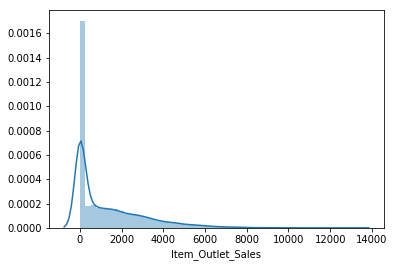

```python
sns.distplot(data['Item_Outlet_Sales'])
```

- As we can see from the distribution plot that the data of Item_Outlet_Sales is not Normally distributed and it is right Skewed

```python
print('Skewness: %f' % data['Item_Outlet_Sales'].skew())
print('Kurtsis: %f' %data['Item_Outlet_Sales'].kurt())
```

```
Skewness: 1.544684
Kurtsis: 2.419439
```

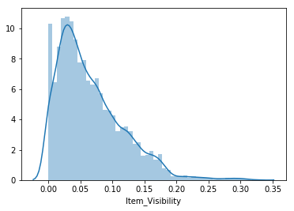

```python
sns.distplot(data['Item_Visibility'])
```

```python
print('Skewness: %f' % data['Item_Visibility'].skew())
print('Kurtsis: %f' %data['Item_Visibility'].kurt())
```

```
Skewness: 1.195175
Kurtsis: 1.820071
```

- As we can see from the distribution plot that the data of Item_Visibility is not Normally distributed and it is right Skewed

#### Let's see the data types of the columns

```python
data.dtypes
```

```
Item_Identifier               object
Item_Weight                  float64
Item_Fat_Content              object
Item_Visibility              float64
Item_Type                     object
Item_MRP                     float64
Outlet_Identifier             object
Outlet_Establishment_Year      int64
Outlet_Size                   object
Outlet_Location_Type          object
Outlet_Type                   object
Item_Outlet_Sales            float64
source                        object
dtype: object
```

```python
## Selecting categorical Features only from the dataset
```

```python
categorial_features = data.select_dtypes(include=[np.object])
categorial_features.head(2)
```

|  | Item_Identifier | Item_Fat_Content | Item_Type | Outlet_Identifier | Outlet_Size | Outlet_Location_Type | Outlet_Type | source |
| --- | --- | --- | --- | --- | --- | --- | --- | --- |
| 0 | FDA15 | Low Fat | Dairy | OUT049 | Medium | Tier 1 | Supermarket Type1 | train |
| 1 | DRC01 | Regular | Soft Drinks | OUT018 | Medium | Tier 3 | Supermarket Type2 | train |

```python
## Selecting Numerical Features only from the dataset
```

```python
numerical_features = data.select_dtypes(include=[np.number])
numerical_features.head(2)
```

|  | Item_Weight | Item_Visibility | Item_MRP | Outlet_Establishment_Year | Item_Outlet_Sales |
| --- | --- | --- | --- | --- | --- |
| 0 | 9.30 | 0.016047 | 249.8092 | 1999 | 3735.1380 |
| 1 | 5.92 | 0.019278 | 48.2692 | 2009 | 443.4228 |

```python
data['Outlet_Establishment_Year'].value_counts()
```

```
1985    2439
1987    1553
1999    1550
1997    1550
2004    1550
2002    1548
2009    1546
2007    1543
1998     925
Name: Outlet_Establishment_Year, dtype: int64
```

### Let's see the missing values in the dataset

```python
data.apply(lambda x: sum(x.isnull()))
```

```
Item_Identifier                 0
Item_Weight                  2439
Item_Fat_Content                0
Item_Visibility                 0
Item_Type                       0
Item_MRP                        0
Outlet_Identifier               0
Outlet_Establishment_Year       0
Outlet_Size                  4016
Outlet_Location_Type            0
Outlet_Type                     0
Item_Outlet_Sales               0
source                          0
dtype: int64
```

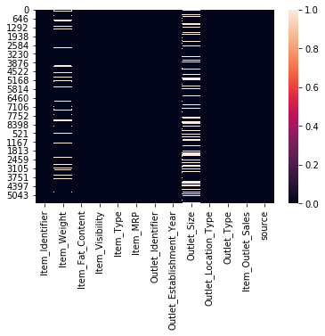

```python
sns.heatmap(data.isnull())
```

- As we can see Item_Weight and Outlet_Size columns is having missing values only.

#### Let's now check the unique values in the dataset

```python
data.apply(lambda x : len(x.unique()))
```

```
Item_Identifier               1559
Item_Weight                    416
Item_Fat_Content                 5
Item_Visibility              13006
Item_Type                       16
Item_MRP                      8052
Outlet_Identifier               10
Outlet_Establishment_Year        9
Outlet_Size                      4
Outlet_Location_Type             3
Outlet_Type                      4
Item_Outlet_Sales             3494
source                           2
dtype: int64
```

- As we can see there are many columns which are having unique values. Like in Item_Identifier there are 1559 different types of items.
- We can infer that there are 416 diffrent types of weights in the datasets

```python
# Let's see the Frequency of diffrent categories in diffrent columns wise.

for col in categorial_features:
    print('\n%s column: '%col)
    print(data[col].value_counts())
```

```
Item_Identifier column:
FDK02    10
FDN56    10
FDE45    10
FDC14    10
FDO01    10
FDD17    10
FDU57    10
FDN01    10
FDG10    10
FDG33    10
FDP37    10
FDO27    10
NCL17    10
NCH30    10
NCF42    10
DRL49    10
FDA13    10
NCV42    10
FDX36    10
NCQ30    10
NCJ17    10
NCT53    10
FDC59    10
NCK29    10
FDO08    10
NCJ19    10
NCN07    10
FDK08    10
DRK59    10
FDP38    10
         ..
NCI55     8
FDR57     8
FDM14     8
FDA51     8
FDU09     8
DRD13     8
DRD49     8
FDD59     8
```

[output cut: 72 more lines]

```
Tier 2    4641
Tier 1    3980
Name: Outlet_Location_Type, dtype: int64

Outlet_Type column:
Supermarket Type1    9294
Grocery Store        1805
Supermarket Type3    1559
Supermarket Type2    1546
Name: Outlet_Type, dtype: int64

source column:
train    8523
test     5681
Name: source, dtype: int64
```

#### Let's see Outlier's in the dataset by ploting it

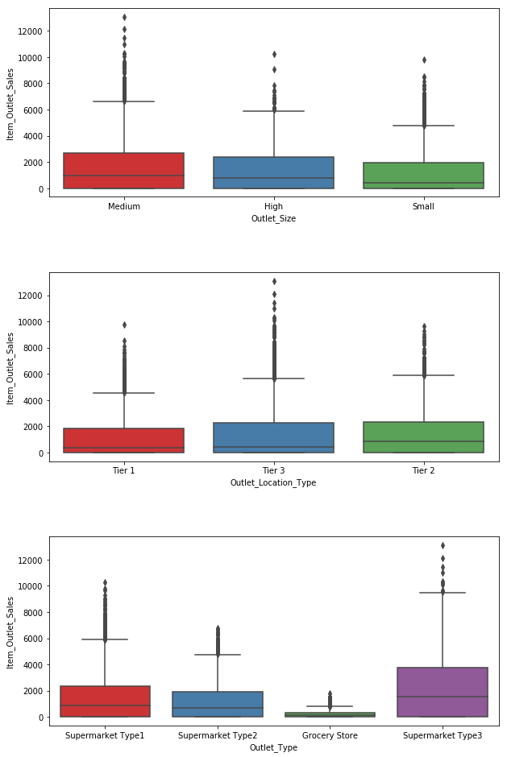

```python
plt.figure(figsize = (10,9))

plt.subplot(311)
sns.boxplot(x='Outlet_Size', y='Item_Outlet_Sales', data=data, palette="Set1")

plt.subplot(312)
sns.boxplot(x='Outlet_Location_Type', y='Item_Outlet_Sales', data=data, palette="Set1")

plt.subplot(313)
sns.boxplot(x='Outlet_Type', y='Item_Outlet_Sales', data=data, palette="Set1")

plt.subplots_adjust(wspace = 0.2, hspace = 0.4,top = 1.5)

plt.show()
```

```python
### Missing values Imputation
```

```python
item_avg_weight = data.pivot_table(values='Item_Weight', index='Item_Identifier')

missing_values = data['Item_Weight'].isnull()
print('Missing values: %d' %sum(missing_values))

data.loc[missing_values,'Item_Weight']  = data.loc[missing_values,'Item_Identifier'].apply(lambda x: item_avg_weight.at[x,'Item_Weight'])
print('Missing values after immputation %d' %sum(data['Item_Weight'].isnull()))
```

```
Missing values: 2439
Missing values after immputation 0
```

```python
#Import mode function:

from scipy.stats import mode

# Determing the mode for each

outlet_size_mode = data.pivot_table(values='Outlet_Size', columns='Outlet_Type',aggfunc=(lambda x:mode(x.astype('str')).mode[0]))
print ('Mode for each Outlet_Type:')
print (outlet_size_mode)

# Get a boolean variable specifying missing Item_Weight values

missing_values = data['Outlet_Size'].isnull()

# Impute data and check #missing values before and after imputation to confirm

print ('\nOrignal #missing: %d'% sum(missing_values))
data.loc[missing_values,'Outlet_Size'] = data.loc[missing_values,'Outlet_Type'].apply(lambda x: outlet_size_mode[x])
print (sum(data['Outlet_Size'].isnull()))
```

```
Mode for each Outlet_Type:
```

```
Outlet_Type Grocery Store Supermarket Type1 Supermarket Type2  \
Outlet_Size           nan             Small            Medium

Outlet_Type Supermarket Type3
Outlet_Size            Medium

Orignal #missing: 4016
0
```

```python
# Determine average visibility of a product

visibility_avg = data.pivot_table(values='Item_Visibility', index='Item_Identifier')

#Impute 0 values with mean visibility of that product:

missing_values = (data['Item_Visibility'] == 0)

print ('Number of 0 values initially: %d'%sum(missing_values))
data.loc[missing_values,'Item_Visibility'] = data.loc[missing_values,'Item_Identifier'].apply(lambda x: visibility_avg.at[x, 'Item_Visibility'])
print ('Number of 0 values after modification: %d'%sum(data['Item_Visibility'] == 0))
```

```
Number of 0 values initially: 879
Number of 0 values after modification: 0
```

```python
#Get the first two characters of ID:
data['Item_Type_Combined'] = data['Item_Identifier'].apply(lambda x: x[0:2])
#Rename them to more intuitive categories:
data['Item_Type_Combined'] = data['Item_Type_Combined'].map({'FD':'Food',
                                                             'NC':'Non-Consumable',
                                                             'DR':'Drinks'})
data['Item_Type_Combined'].value_counts()
```

```
Food              10201
Non-Consumable     2686
Drinks             1317
Name: Item_Type_Combined, dtype: int64
```

```python
#Change categories of low fat:
print('Original Categories:')
print(data['Item_Fat_Content'].value_counts())

print('\nModified Categories:')
data['Item_Fat_Content'] = data['Item_Fat_Content'].replace({'LF':'Low Fat',
                                                             'reg':'Regular',
                                                             'low fat':'Low Fat'})
print(data['Item_Fat_Content'].value_counts())
```

```
Original Categories:
Low Fat    8485
Regular    4824
LF          522
reg         195
low fat     178
Name: Item_Fat_Content, dtype: int64

Modified Categories:
Low Fat    9185
Regular    5019
Name: Item_Fat_Content, dtype: int64
```

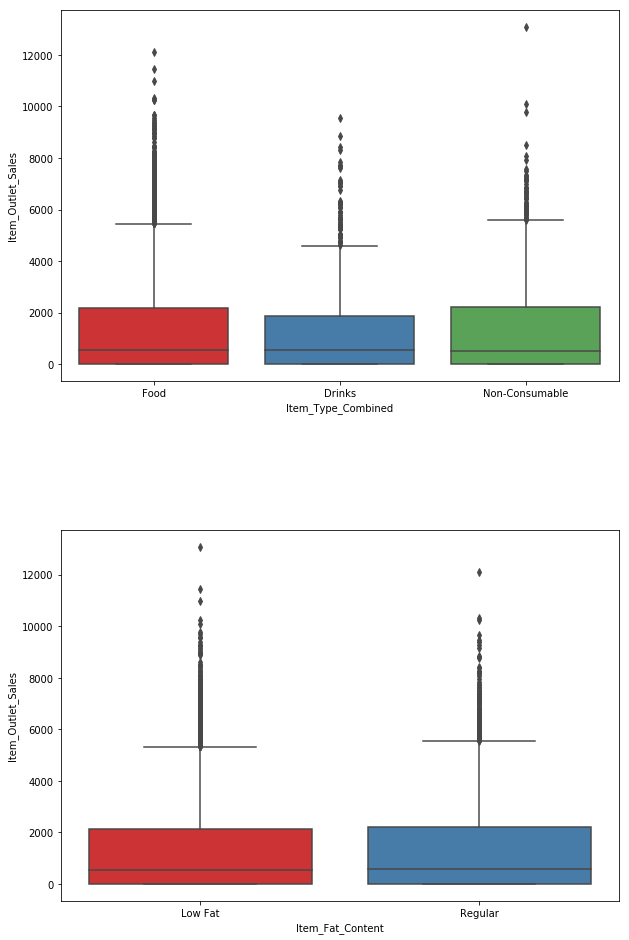

```python
plt.figure(figsize = (10,9))

plt.subplot(211)
sns.boxplot(x='Item_Type_Combined', y='Item_Outlet_Sales', data=data, palette="Set1")

plt.subplot(212)
sns.boxplot(x='Item_Fat_Content', y='Item_Outlet_Sales', data=data, palette="Set1")

plt.subplots_adjust(wspace = 0.2, hspace = 0.4,top = 1.5)

plt.show()
```

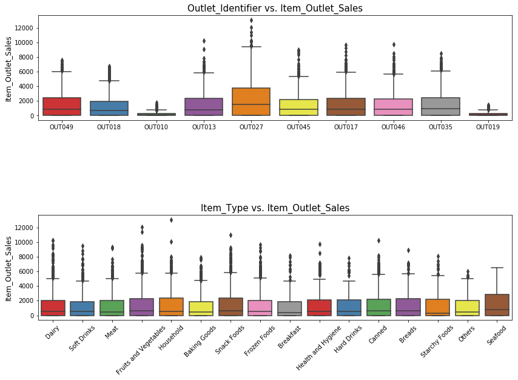

```python
plt.figure(figsize = (14,9))

plt.subplot(211)
ax = sns.boxplot(x='Outlet_Identifier', y='Item_Outlet_Sales', data=data, palette="Set1")
ax.set_title("Outlet_Identifier vs. Item_Outlet_Sales", fontsize=15)
ax.set_xlabel("", fontsize=12)
ax.set_ylabel("Item_Outlet_Sales", fontsize=12)

plt.subplot(212)
ax = sns.boxplot(x='Item_Type', y='Item_Outlet_Sales', data=data, palette="Set1")
ax.set_title("Item_Type vs. Item_Outlet_Sales", fontsize=15)
ax.set_xlabel("", fontsize=12)
ax.set_ylabel("Item_Outlet_Sales", fontsize=12)

plt.subplots_adjust(hspace = 0.9, top = 0.9)
plt.setp(ax.get_xticklabels(), rotation=45)

plt.show()
```

```python
data.index = data['Outlet_Establishment_Year']
data.index
```

```
Int64Index([1999, 2009, 1999, 1998, 1987, 2009, 1987, 1985, 2002, 2007,
            ...
            1999, 1999, 2009, 1997, 1999, 1997, 2009, 2002, 2007, 2002],
           dtype='int64', name='Outlet_Establishment_Year', length=14204)
```

```python
df = data.loc[:,['Item_Outlet_Sales']]
df.head(2)
```

| Outlet_Establishment_Year | Item_Outlet_Sales |
| --- | --- |
| 1999 | 3735.1380 |
| 2009 | 443.4228 |

```python
data['Outlet_Years'] = 2009 - data['Outlet_Establishment_Year']
data['Outlet_Years'].describe()
```

```
count    14204.000000
mean        11.169319
std          8.371664
min          0.000000
25%          5.000000
50%         10.000000
75%         22.000000
max         24.000000
Name: Outlet_Years, dtype: float64
```

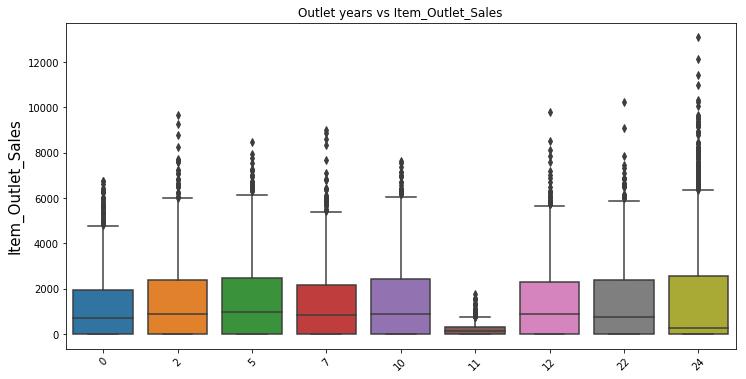

```python
plt.figure(figsize = (12,6))
ax = sns.boxplot(x = 'Outlet_Years', y = 'Item_Outlet_Sales', data = data)
ax.set_xticklabels(ax.get_xticklabels(), rotation = 45)
ax.set_title('Outlet years vs Item_Outlet_Sales')
ax.set_xlabel('', fontsize = 15)
ax.set_ylabel('Item_Outlet_Sales', fontsize = 15)

plt.show()
```

```python
temp_data = data.loc[data['Outlet_Establishment_Year'] == 1998]
```

```python
temp_data['Outlet_Type'].value_counts()
```

```
Grocery Store    925
Name: Outlet_Type, dtype: int64
```

```python
test_temp_data = test.loc[test['Outlet_Establishment_Year'] == 1998]
test_temp_data['Outlet_Type'].value_counts()
```

```
Grocery Store    370
Name: Outlet_Type, dtype: int64
```

### Applying Encoding Technique's

```python
#Import library:

# Applying Label Encoding

from sklearn.preprocessing import LabelEncoder
le = LabelEncoder()

#New variable for outlet
data['Outlet'] = le.fit_transform(data['Outlet_Identifier'])
var_mod = ['Item_Fat_Content','Outlet_Location_Type','Outlet_Size','Item_Type_Combined','Outlet_Type','Outlet']
le = LabelEncoder()
for i in var_mod:
    data[i] = le.fit_transform(data[i])
```

```python
# Applying One Hot Coding:

data = pd.get_dummies(data, columns=['Item_Fat_Content','Outlet_Location_Type','Outlet_Size','Outlet_Type',
                              'Item_Type_Combined','Outlet'])
```

```python
data.dtypes
```

```
Item_Identifier               object
Item_Weight                  float64
Item_Visibility              float64
Item_Type                     object
Item_MRP                     float64
Outlet_Identifier             object
Outlet_Establishment_Year      int64
Item_Outlet_Sales            float64
source                        object
Outlet_Years                   int64
Item_Fat_Content_0             uint8
Item_Fat_Content_1             uint8
Outlet_Location_Type_0         uint8
Outlet_Location_Type_1         uint8
Outlet_Location_Type_2         uint8
Outlet_Size_0                  uint8
Outlet_Size_1                  uint8
Outlet_Size_2                  uint8
Outlet_Size_3                  uint8
Outlet_Type_0                  uint8
Outlet_Type_1                  uint8
Outlet_Type_2                  uint8
Outlet_Type_3                  uint8
Item_Type_Combined_0           uint8
Item_Type_Combined_1           uint8
Item_Type_Combined_2           uint8
Outlet_0                       uint8
Outlet_1                       uint8
Outlet_2                       uint8
Outlet_3                       uint8
Outlet_4                       uint8
Outlet_5                       uint8
Outlet_6                       uint8
Outlet_7                       uint8
Outlet_8                       uint8
Outlet_9                       uint8
dtype: object
```

```python
# Drop the columns which have been converted to different types:


data.drop(['Item_Type','Outlet_Establishment_Year'],axis=1,inplace=True)

# Divide into test and train:

train = data.loc[data['source']=="train"]
test = data.loc[data['source']=="test"]

# Drop unnecessary columns:

test.drop(['Item_Outlet_Sales','source'],axis=1,inplace=True)
train.drop(['source'],axis=1,inplace=True)
```

```python
train.head()
```

| Outlet_Establishment_Year | Item_Identifier | Item_Weight | Item_Visibility | Item_MRP | Outlet_Identifier | Item_Outlet_Sales | Outlet_Years | Item_Fat_Content_0 | Item_Fat_Content_1 | Outlet_Location_Type_0 | ... | Outlet_0 | Outlet_1 | Outlet_2 | Outlet_3 | Outlet_4 | Outlet_5 | Outlet_6 | Outlet_7 | Outlet_8 | Outlet_9 |
| --- | --- | --- | --- | --- | --- | --- | --- | --- | --- | --- | --- | --- | --- | --- | --- | --- | --- | --- | --- | --- | --- |
| 1999 | FDA15 | 9.30 | 0.016047 | 249.8092 | OUT049 | 3735.1380 | 10 | 1 | 0 | 1 | ... | 0 | 0 | 0 | 0 | 0 | 0 | 0 | 0 | 0 | 1 |
| 2009 | DRC01 | 5.92 | 0.019278 | 48.2692 | OUT018 | 443.4228 | 0 | 0 | 1 | 0 | ... | 0 | 0 | 0 | 1 | 0 | 0 | 0 | 0 | 0 | 0 |
| 1999 | FDN15 | 17.50 | 0.016760 | 141.6180 | OUT049 | 2097.2700 | 10 | 1 | 0 | 1 | ... | 0 | 0 | 0 | 0 | 0 | 0 | 0 | 0 | 0 | 1 |
| 1998 | FDX07 | 19.20 | 0.017834 | 182.0950 | OUT010 | 732.3800 | 11 | 0 | 1 | 0 | ... | 1 | 0 | 0 | 0 | 0 | 0 | 0 | 0 | 0 | 0 |
| 1987 | NCD19 | 8.93 | 0.009780 | 53.8614 | OUT013 | 994.7052 | 22 | 1 | 0 | 0 | ... | 0 | 1 | 0 | 0 | 0 | 0 | 0 | 0 | 0 | 0 |

5 rows × 33 columns

```python
test.head()
```

| Outlet_Establishment_Year | Item_Identifier | Item_Weight | Item_Visibility | Item_MRP | Outlet_Identifier | Outlet_Years | Item_Fat_Content_0 | Item_Fat_Content_1 | Outlet_Location_Type_0 | Outlet_Location_Type_1 | ... | Outlet_0 | Outlet_1 | Outlet_2 | Outlet_3 | Outlet_4 | Outlet_5 | Outlet_6 | Outlet_7 | Outlet_8 | Outlet_9 |
| --- | --- | --- | --- | --- | --- | --- | --- | --- | --- | --- | --- | --- | --- | --- | --- | --- | --- | --- | --- | --- | --- |
| 1999 | FDW58 | 20.750 | 0.007565 | 107.8622 | OUT049 | 10 | 1 | 0 | 1 | 0 | ... | 0 | 0 | 0 | 0 | 0 | 0 | 0 | 0 | 0 | 1 |
| 2007 | FDW14 | 8.300 | 0.038428 | 87.3198 | OUT017 | 2 | 0 | 1 | 0 | 1 | ... | 0 | 0 | 1 | 0 | 0 | 0 | 0 | 0 | 0 | 0 |
| 1998 | NCN55 | 14.600 | 0.099575 | 241.7538 | OUT010 | 11 | 1 | 0 | 0 | 0 | ... | 1 | 0 | 0 | 0 | 0 | 0 | 0 | 0 | 0 | 0 |
| 2007 | FDQ58 | 7.315 | 0.015388 | 155.0340 | OUT017 | 2 | 1 | 0 | 0 | 1 | ... | 0 | 0 | 1 | 0 | 0 | 0 | 0 | 0 | 0 | 0 |
| 1985 | FDY38 | 13.600 | 0.118599 | 234.2300 | OUT027 | 24 | 0 | 1 | 0 | 0 | ... | 0 | 0 | 0 | 0 | 0 | 1 | 0 | 0 | 0 | 0 |

5 rows × 32 columns

### As our dataset is ready for the implementation of Machine Learning algorithms. Now we will apply Linear Regression and Check our Acuracy

### STEP-1: Setting dependent and independent variables

```python
X = train.drop(["Item_Outlet_Sales","Item_Identifier","Outlet_Identifier"],axis=1)   # independent variables
X.head()
```

| Outlet_Establishment_Year | Item_Weight | Item_Visibility | Item_MRP | Outlet_Years | Item_Fat_Content_0 | Item_Fat_Content_1 | Outlet_Location_Type_0 | Outlet_Location_Type_1 | Outlet_Location_Type_2 | Outlet_Size_0 | ... | Outlet_0 | Outlet_1 | Outlet_2 | Outlet_3 | Outlet_4 | Outlet_5 | Outlet_6 | Outlet_7 | Outlet_8 | Outlet_9 |
| --- | --- | --- | --- | --- | --- | --- | --- | --- | --- | --- | --- | --- | --- | --- | --- | --- | --- | --- | --- | --- | --- |
| 1999 | 9.30 | 0.016047 | 249.8092 | 10 | 1 | 0 | 1 | 0 | 0 | 0 | ... | 0 | 0 | 0 | 0 | 0 | 0 | 0 | 0 | 0 | 1 |
| 2009 | 5.92 | 0.019278 | 48.2692 | 0 | 0 | 1 | 0 | 0 | 1 | 0 | ... | 0 | 0 | 0 | 1 | 0 | 0 | 0 | 0 | 0 | 0 |
| 1999 | 17.50 | 0.016760 | 141.6180 | 10 | 1 | 0 | 1 | 0 | 0 | 0 | ... | 0 | 0 | 0 | 0 | 0 | 0 | 0 | 0 | 0 | 1 |
| 1998 | 19.20 | 0.017834 | 182.0950 | 11 | 0 | 1 | 0 | 0 | 1 | 0 | ... | 1 | 0 | 0 | 0 | 0 | 0 | 0 | 0 | 0 | 0 |
| 1987 | 8.93 | 0.009780 | 53.8614 | 22 | 1 | 0 | 0 | 0 | 1 | 1 | ... | 0 | 1 | 0 | 0 | 0 | 0 | 0 | 0 | 0 | 0 |

5 rows × 30 columns

```python
Y = train["Item_Outlet_Sales"]          # dependent variables
Y.head()
```

```
Outlet_Establishment_Year
1999    3735.1380
2009     443.4228
1999    2097.2700
1998     732.3800
1987     994.7052
Name: Item_Outlet_Sales, dtype: float64
```

### STEP-2 Splitting the data set in training and testing sets

```python
from sklearn.model_selection import train_test_split    #this is used for splitting data into training and testing set
from sklearn.linear_model import LinearRegression       # this is used for LinearRegression
from sklearn.linear_model import Ridge, Lasso
```

```python
x_train,x_test,y_train,y_test = train_test_split(X,Y,test_size=0.2,random_state=0)
print(len(x_train),len(x_test),len(y_train),len(y_test))
```

```
6818 1705 6818 1705
```

### STEP-3 Creating LinearRegression object & fitting training set

```python
reg = LinearRegression()
reg.fit(x_train,y_train)
```

```
LinearRegression(copy_X=True, fit_intercept=True, n_jobs=None,
         normalize=False)
```

### STEP-4 Calculating slope and intercept

```python
print("ai",reg.coef_)
print("a0=",reg.intercept_)
```

```
ai [  -1.7454225  -225.69950399   15.52916102   12.99390958  -16.94079581
   16.94079581 -244.7107569   177.19396394   67.51679296  -75.35934281
  446.49765925  -34.26639483 -336.87192161 -854.96072507  375.2126677
 -113.28065791  593.02871529   -8.51446036   18.37222226   -9.8577619
 -336.87192161  -75.35934281  148.3574148  -113.28065791 -518.08880346
  593.02871529  133.83766166 -105.00111252  306.6284447   -33.25039813]
a0= -460.2585564773258
```

### STEP-5 Caclculatig prediction on x_test

```python
y_pred = reg.predict(x_test)
y_pred
```

```
array([ 2449.26590934,  2530.1553465 ,  2194.90302677, ...,
        4165.56906997, -1031.81919302,  5395.89890935])
```

### STEP-6 Model Evaluation by Calculating RMSE AND R2 SCORE

```python
from sklearn.metrics import r2_score
from sklearn.metrics import mean_squared_error

rmse = np.sqrt(mean_squared_error(y_test,y_pred))
r2 = r2_score(y_test,y_pred)

print("RMSE =", rmse)
print("R2 Score=",r2)
```

```
RMSE = 1129.4188711586978
R2 Score= 0.5641789409156743
```

### STEP-7 Calaculatin Residue or Error

```python
residue = y_test - y_pred                   # this is the formulae for residue/error
print(residue)
```

```
Outlet_Establishment_Year
2002   -1023.122309
1985   -1328.386346
2007    -358.626627
2007       7.332469
1987   -1550.223221
1997    -420.556288
1985    -893.018792
2002   -1046.165863
1998    -725.087635
2009    -238.413271
1987     600.528809
2009    -240.095434
2009    -581.981055
1999   -1007.780261
```

[output cut: 48 more lines]

### Plotting Graph of Residual Plot

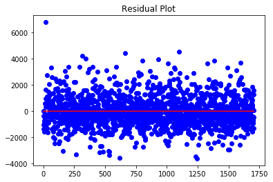

```python
x = [i for i in range(1,len(y_pred)+1)]

x_plot = plt.scatter(x,(y_test - y_pred),c="b")      # (y_test - y_pred) = residue
plt.plot(x,[0]*len(y_pred),c="r")

plt.title("Residual Plot")
```

### Applying Regularization Technique's

```
- Ridge Regression
- Lasso Regression
```

```python
predictors = x_train.columns
predictors
```

```
Index(['Item_Weight', 'Item_Visibility', 'Item_MRP', 'Outlet_Years',
       'Item_Fat_Content_0', 'Item_Fat_Content_1', 'Outlet_Location_Type_0',
       'Outlet_Location_Type_1', 'Outlet_Location_Type_2', 'Outlet_Size_0',
       'Outlet_Size_1', 'Outlet_Size_2', 'Outlet_Size_3', 'Outlet_Type_0',
       'Outlet_Type_1', 'Outlet_Type_2', 'Outlet_Type_3',
       'Item_Type_Combined_0', 'Item_Type_Combined_1', 'Item_Type_Combined_2',
       'Outlet_0', 'Outlet_1', 'Outlet_2', 'Outlet_3', 'Outlet_4', 'Outlet_5',
       'Outlet_6', 'Outlet_7', 'Outlet_8', 'Outlet_9'],
      dtype='object')
```

```python
coef = pd.Series(reg.coef_,predictors)
coef
```

```
Item_Weight                -1.745423
Item_Visibility          -225.699504
Item_MRP                   15.529161
Outlet_Years               12.993910
Item_Fat_Content_0        -16.940796
Item_Fat_Content_1         16.940796
Outlet_Location_Type_0   -244.710757
Outlet_Location_Type_1    177.193964
Outlet_Location_Type_2     67.516793
Outlet_Size_0             -75.359343
Outlet_Size_1             446.497659
Outlet_Size_2             -34.266395
Outlet_Size_3            -336.871922
Outlet_Type_0            -854.960725
Outlet_Type_1             375.212668
Outlet_Type_2            -113.280658
Outlet_Type_3             593.028715
Item_Type_Combined_0       -8.514460
Item_Type_Combined_1       18.372222
Item_Type_Combined_2       -9.857762
Outlet_0                 -336.871922
Outlet_1                  -75.359343
Outlet_2                  148.357415
Outlet_3                 -113.280658
Outlet_4                 -518.088803
Outlet_5                  593.028715
Outlet_6                  133.837662
Outlet_7                 -105.001113
Outlet_8                  306.628445
Outlet_9                  -33.250398
dtype: float64
```

```python
coef = pd.Series(reg.coef_,predictors).sort_values()
coef
```

```
Outlet_Type_0            -854.960725
Outlet_4                 -518.088803
Outlet_Size_3            -336.871922
Outlet_0                 -336.871922
Outlet_Location_Type_0   -244.710757
Item_Visibility          -225.699504
Outlet_Type_2            -113.280658
Outlet_3                 -113.280658
Outlet_7                 -105.001113
Outlet_1                  -75.359343
Outlet_Size_0             -75.359343
Outlet_Size_2             -34.266395
Outlet_9                  -33.250398
Item_Fat_Content_0        -16.940796
Item_Type_Combined_2       -9.857762
Item_Type_Combined_0       -8.514460
Item_Weight                -1.745423
Outlet_Years               12.993910
Item_MRP                   15.529161
Item_Fat_Content_1         16.940796
Item_Type_Combined_1       18.372222
Outlet_Location_Type_2     67.516793
Outlet_6                  133.837662
Outlet_2                  148.357415
Outlet_Location_Type_1    177.193964
Outlet_8                  306.628445
Outlet_Type_1             375.212668
Outlet_Size_1             446.497659
Outlet_5                  593.028715
Outlet_Type_3             593.028715
dtype: float64
```

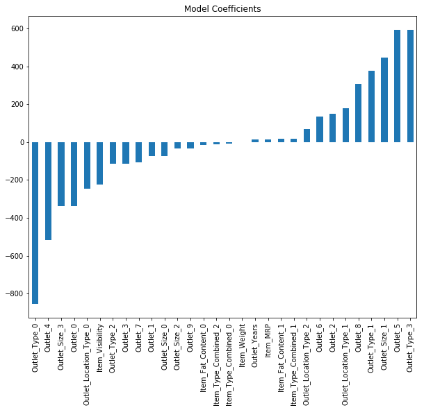

```python
plt.figure(figsize=(10,8))
coef.plot(title="Model Coefficients",kind="bar")
```

#### Applying Ridge Regression and checking if it give us better accuracy or not

```python
from sklearn.linear_model import Ridge
ridgeReg = Ridge(alpha=0.05,normalize=True)
ridgeReg.fit(x_train,y_train)
pred = ridgeReg.predict(x_test)
rmse = np.sqrt(mean_squared_error(y_test,pred))
r2=r2_score(y_test,pred)

print("RMSE= ",rmse,'R2=',r2)
```

```
RMSE=  1130.788523459092 R2= 0.5631212549190345
```

```python
ridgeReg = Ridge(alpha=0.01,normalize=True)
ridgeReg.fit(x_train,y_train)
pred = ridgeReg.predict(x_test)
rmse = np.sqrt(mean_squared_error(y_test,pred))
r2=r2_score(y_test,pred)

print("RMSE= ",rmse,'R2=',r2)
```

```
RMSE=  1129.5337568212638 R2= 0.5640902720630863
```

```python
ridgeReg = Ridge(alpha=0.001,normalize=True)
ridgeReg.fit(x_train,y_train)
pred = ridgeReg.predict(x_test)
rmse = np.sqrt(mean_squared_error(y_test,pred))
r2=r2_score(y_test,pred)

print("RMSE= ",rmse,'R2=',r2)
```

```
RMSE=  1129.4264316082263 R2= 0.5641731060314994
```

#### Applying Lasso Regression and checking if it give us better accuracy or not

```python
from sklearn.linear_model import Lasso
LassoReg = Lasso(alpha=0.1,normalize=True)
LassoReg.fit(x_train,y_train)
pred = LassoReg.predict(x_test)
rmse = np.sqrt(mean_squared_error(y_test,pred))
r2=r2_score(y_test,pred)

print("RMSE= ",rmse,'R2=',r2)
```

```
RMSE=  1129.1107722938264 R2= 0.5644166873570862
```

#### As we can see from our 1st trail we are getting almost same accuracy in all our Model's.

## Now we will try some diffrent technique's and see if our accuracy improve's or not.

# 2nd Trail

```python
train1 = pd.read_csv("Training.csv")
train1.head(3)
```

|  | Item_Identifier | Item_Weight | Item_Fat_Content | Item_Visibility | Item_Type | Item_MRP | Outlet_Identifier | Outlet_Establishment_Year | Outlet_Size | Outlet_Location_Type | Outlet_Type | Item_Outlet_Sales |
| --- | --- | --- | --- | --- | --- | --- | --- | --- | --- | --- | --- | --- |
| 0 | FDA15 | 9.30 | Low Fat | 0.016047 | Dairy | 249.8092 | OUT049 | 1999 | Medium | Tier 1 | Supermarket Type1 | 3735.1380 |
| 1 | DRC01 | 5.92 | Regular | 0.019278 | Soft Drinks | 48.2692 | OUT018 | 2009 | Medium | Tier 3 | Supermarket Type2 | 443.4228 |
| 2 | FDN15 | 17.50 | Low Fat | 0.016760 | Meat | 141.6180 | OUT049 | 1999 | Medium | Tier 1 | Supermarket Type1 | 2097.2700 |

```python
test1 = pd.read_csv("Testing.csv")
test1.head(3)
```

|  | Item_Identifier | Item_Weight | Item_Fat_Content | Item_Visibility | Item_Type | Item_MRP | Outlet_Identifier | Outlet_Establishment_Year | Outlet_Size | Outlet_Location_Type | Outlet_Type |
| --- | --- | --- | --- | --- | --- | --- | --- | --- | --- | --- | --- |
| 0 | FDW58 | 20.75 | Low Fat | 0.007565 | Snack Foods | 107.8622 | OUT049 | 1999 | Medium | Tier 1 | Supermarket Type1 |
| 1 | FDW14 | 8.30 | reg | 0.038428 | Dairy | 87.3198 | OUT017 | 2007 | NaN | Tier 2 | Supermarket Type1 |
| 2 | NCN55 | 14.60 | Low Fat | 0.099575 | Others | 241.7538 | OUT010 | 1998 | NaN | Tier 3 | Grocery Store |

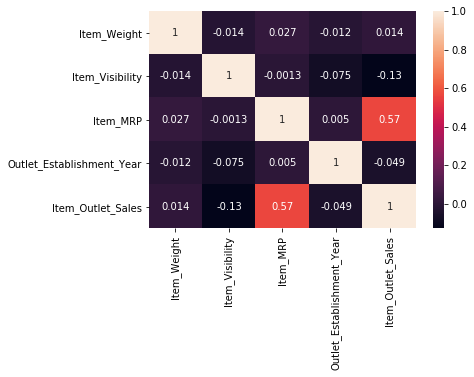

```python
# View the relationships between individual features as well as between the features and the dependent variable.

corr = train1.corr()

#Heatmaps show the strenght of relationships between the data features.

sns.heatmap(corr, annot=True)
```

```python
train1.describe()
```

|  | Item_Weight | Item_Visibility | Item_MRP | Outlet_Establishment_Year | Item_Outlet_Sales |
| --- | --- | --- | --- | --- | --- |
| count | 7060.000000 | 8523.000000 | 8523.000000 | 8523.000000 | 8523.000000 |
| mean | 12.857645 | 0.066132 | 140.992782 | 1997.831867 | 2181.288914 |
| std | 4.643456 | 0.051598 | 62.275067 | 8.371760 | 1706.499616 |
| min | 4.555000 | 0.000000 | 31.290000 | 1985.000000 | 33.290000 |
| 25% | 8.773750 | 0.026989 | 93.826500 | 1987.000000 | 834.247400 |
| 50% | 12.600000 | 0.053931 | 143.012800 | 1999.000000 | 1794.331000 |
| 75% | 16.850000 | 0.094585 | 185.643700 | 2004.000000 | 3101.296400 |
| max | 21.350000 | 0.328391 | 266.888400 | 2009.000000 | 13086.964800 |

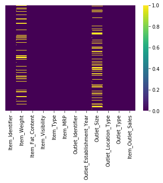

```python
# visualizing the data to detect missing values

sns.heatmap(train1.isnull(),yticklabels=False,cmap='viridis')
```

```python
# Impute the missing values in the Out_let size column.


train1.Outlet_Size = train1.Outlet_Size.fillna('Medium')
```

```python
# Impute Missing values in the Item_Weight column by the mean value.


train1.Item_Weight = train1.Item_Weight.fillna(12.86)
```

```python
train1.head(5)
```

|  | Item_Identifier | Item_Weight | Item_Fat_Content | Item_Visibility | Item_Type | Item_MRP | Outlet_Identifier | Outlet_Establishment_Year | Outlet_Size | Outlet_Location_Type | Outlet_Type | Item_Outlet_Sales |
| --- | --- | --- | --- | --- | --- | --- | --- | --- | --- | --- | --- | --- |
| 0 | FDA15 | 9.30 | Low Fat | 0.016047 | Dairy | 249.8092 | OUT049 | 1999 | Medium | Tier 1 | Supermarket Type1 | 3735.1380 |
| 1 | DRC01 | 5.92 | Regular | 0.019278 | Soft Drinks | 48.2692 | OUT018 | 2009 | Medium | Tier 3 | Supermarket Type2 | 443.4228 |
| 2 | FDN15 | 17.50 | Low Fat | 0.016760 | Meat | 141.6180 | OUT049 | 1999 | Medium | Tier 1 | Supermarket Type1 | 2097.2700 |
| 3 | FDX07 | 19.20 | Regular | 0.000000 | Fruits and Vegetables | 182.0950 | OUT010 | 1998 | Medium | Tier 3 | Grocery Store | 732.3800 |
| 4 | NCD19 | 8.93 | Low Fat | 0.000000 | Household | 53.8614 | OUT013 | 1987 | High | Tier 3 | Supermarket Type1 | 994.7052 |

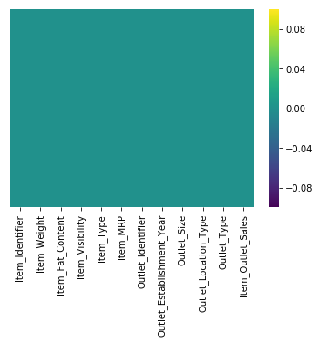

```python
# Visualizing the data to detect/Review presence of missing values


sns.heatmap(train1.isnull(),yticklabels=False,cmap='viridis')
```

## Changing categorical data to numerical data.

```python
# Changing categorical data(Outlet_Location_Type) to numerical data.


train1["Outlet_Location_Type"] = pd.Categorical(train1["Outlet_Location_Type"])
Outlet_Location_Type_categories = train1.Outlet_Location_Type.cat.categories
train1["Outlet_Location_Type"] = train1.Outlet_Location_Type.cat.codes
```

```python
# Changing categorical data(Outlet_Size) to numerical data.


train1["Outlet_Size"] = pd.Categorical(train1["Outlet_Size"])
Outlet_Size_categories = train1.Outlet_Size.cat.categories
train1["Outlet_Size"] = train1.Outlet_Size.cat.codes
```

```python
# Changing categorical data(Item_Fat_Content) to numerical data.


train1["Item_Fat_Content"] = pd.Categorical(train1["Item_Fat_Content"])
Item_Fat_Content_categories = train1.Item_Fat_Content.cat.categories
train1["Item_Fat_Content"] = train1.Item_Fat_Content.cat.codes
```

```python
# Changing categorical data(Item_Type) to numerical data.


train1["Item_Type"] = pd.Categorical(train1["Item_Type"])
Item_Type_categories = train1.Item_Type.cat.categories
train1["Item_Type"] = train1.Item_Type.cat.codes
```

```python
# Changing categorical data(Outlet_Type) to numerical data.


train1["Outlet_Type"] = pd.Categorical(train1["Outlet_Type"])
Outlet_Type_categories = train1.Outlet_Type.cat.categories
train1["Outlet_Type"] = train1.Outlet_Type.cat.codes
```

```python
# Changing categorical data(Outlet_Identifier) to numerical data.


train1["Outlet_Identifier"] = pd.Categorical(train1["Outlet_Identifier"])
Outlet_Identifier_categories = train1.Outlet_Identifier.cat.categories
train1["Outlet_Identifier"] = train1.Outlet_Identifier.cat.codes
```

```python
# Changing categorical data(Outlet_Establishment_Year) to numerical data.


train1["Outlet_Establishment_Year"] = pd.Categorical(train1["Outlet_Establishment_Year"])
Outlet_Establishment_Year_categories = train1.Outlet_Establishment_Year.cat.categories
train1["Outlet_Establishment_Year"] = train1.Outlet_Establishment_Year.cat.codes
```

```python
# Training data after categorical to numerical conversions.


train1.head()
```

|  | Item_Identifier | Item_Weight | Item_Fat_Content | Item_Visibility | Item_Type | Item_MRP | Outlet_Identifier | Outlet_Establishment_Year | Outlet_Size | Outlet_Location_Type | Outlet_Type | Item_Outlet_Sales |
| --- | --- | --- | --- | --- | --- | --- | --- | --- | --- | --- | --- | --- |
| 0 | FDA15 | 9.30 | 1 | 0.016047 | 4 | 249.8092 | 9 | 4 | 1 | 0 | 1 | 3735.1380 |
| 1 | DRC01 | 5.92 | 2 | 0.019278 | 14 | 48.2692 | 3 | 8 | 1 | 2 | 2 | 443.4228 |
| 2 | FDN15 | 17.50 | 1 | 0.016760 | 10 | 141.6180 | 9 | 4 | 1 | 0 | 1 | 2097.2700 |
| 3 | FDX07 | 19.20 | 2 | 0.000000 | 6 | 182.0950 | 0 | 3 | 1 | 2 | 0 | 732.3800 |
| 4 | NCD19 | 8.93 | 1 | 0.000000 | 9 | 53.8614 | 1 | 1 | 0 | 2 | 1 | 994.7052 |

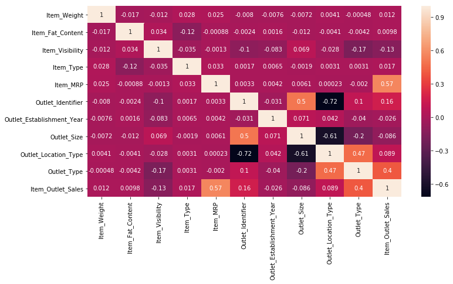

```python
# A correlation analysis will indicate additional relationships in the dataset

plt.figure(figsize=(12,6))
corr = train1.corr()
sns.heatmap(corr, annot=True)
```

### Applying Machine Learning Technique's

#### STEP-1: Setting dependent and independent variables

```python
X=train1.drop(["Item_Outlet_Sales","Item_Identifier"],axis=1)   # independent variables
X.head()
```

|  | Item_Weight | Item_Fat_Content | Item_Visibility | Item_Type | Item_MRP | Outlet_Identifier | Outlet_Establishment_Year | Outlet_Size | Outlet_Location_Type | Outlet_Type |
| --- | --- | --- | --- | --- | --- | --- | --- | --- | --- | --- |
| 0 | 9.30 | 1 | 0.016047 | 4 | 249.8092 | 9 | 4 | 1 | 0 | 1 |
| 1 | 5.92 | 2 | 0.019278 | 14 | 48.2692 | 3 | 8 | 1 | 2 | 2 |
| 2 | 17.50 | 1 | 0.016760 | 10 | 141.6180 | 9 | 4 | 1 | 0 | 1 |
| 3 | 19.20 | 2 | 0.000000 | 6 | 182.0950 | 0 | 3 | 1 | 2 | 0 |
| 4 | 8.93 | 1 | 0.000000 | 9 | 53.8614 | 1 | 1 | 0 | 2 | 1 |

```python
Y = train1["Item_Outlet_Sales"]          # dependent variables
Y.head()
```

```
0    3735.1380
1     443.4228
2    2097.2700
3     732.3800
4     994.7052
Name: Item_Outlet_Sales, dtype: float64
```

#### STEP-2 Splitting the data set in training and testing sets

```python
from sklearn.model_selection import train_test_split    #this is used for splitting data into training and testing set
from sklearn.linear_model import LinearRegression       # this is used for LinearRegression
from sklearn.linear_model import Ridge, Lasso
```

```python
x_train,x_test,y_train,y_test = train_test_split(X,Y,test_size=0.20,random_state = 0)
print(len(x_train),len(x_test),len(y_train),len(y_test))
```

```
6818 1705 6818 1705
```

#### STEP-3 Creating LinearRegression object & fitting training set

```python
reg = LinearRegression()
reg.fit(x_train,y_train)
```

```
LinearRegression(copy_X=True, fit_intercept=True, n_jobs=None,
         normalize=False)
```

#### STEP-4 Calculating slope and intercept

```python
print("a1,a2,a3,a4,a5,a6,a7,a8,a9,a10",reg.coef_)
print("a0=",reg.intercept_)
```

```
a1,a2,a3,a4,a5,a6,a7,a8,a9,a10 [-2.39232331e+00  2.69040944e+01 -1.40013247e+03  3.38346631e-01
  1.55538771e+01  6.00923653e+01  3.77249256e+00 -3.39206404e+02
 -2.22566278e+02  8.77672169e+02]
a0= -631.616522383933
```

#### STEP-5 Caclculatig prediction on x_test

```python
y_pred = reg.predict(x_test)
y_pred
```

```
array([2474.54074032, 2508.72857302, 1824.88926364, ..., 3859.812667  ,
       -449.32348265, 5353.93478615])
```

#### STEP-6 Model Evaluation by Calculating RMSE AND R2 SCORE

```python
from sklearn.metrics import r2_score
from sklearn.metrics import mean_squared_error

rmse = np.sqrt(mean_squared_error(y_test,y_pred))
r2 = r2_score(y_test,y_pred)

print("RMSE =", rmse)
print("R2 Score=",r2)
```

```
RMSE = 1194.1715214932683
R2 Score= 0.51277277036315
```

```python
predictors = x_train.columns
predictors
```

```
Index(['Item_Weight', 'Item_Fat_Content', 'Item_Visibility', 'Item_Type',
       'Item_MRP', 'Outlet_Identifier', 'Outlet_Establishment_Year',
       'Outlet_Size', 'Outlet_Location_Type', 'Outlet_Type'],
      dtype='object')
```

### Applying Regularization

```python
coef = pd.Series(reg.coef_,predictors)
coef
```

```
Item_Weight                    -2.392323
Item_Fat_Content               26.904094
Item_Visibility             -1400.132468
Item_Type                       0.338347
Item_MRP                       15.553877
Outlet_Identifier              60.092365
Outlet_Establishment_Year       3.772493
Outlet_Size                  -339.206404
Outlet_Location_Type         -222.566278
Outlet_Type                   877.672169
dtype: float64
```

```python
coef = pd.Series(reg.coef_,predictors).sort_values()
coef
```

```
Item_Visibility             -1400.132468
Outlet_Size                  -339.206404
Outlet_Location_Type         -222.566278
Item_Weight                    -2.392323
Item_Type                       0.338347
Outlet_Establishment_Year       3.772493
Item_MRP                       15.553877
Item_Fat_Content               26.904094
Outlet_Identifier              60.092365
Outlet_Type                   877.672169
dtype: float64
```

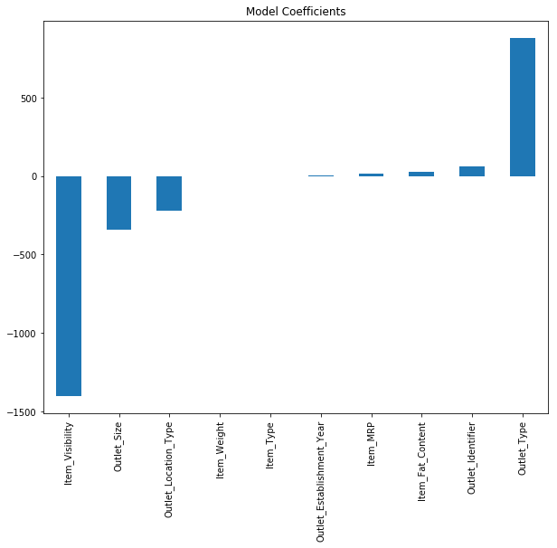

```python
plt.figure(figsize=(10,8))
coef.plot(title="Model Coefficients",kind="bar")
```

### Ridge Regression

```python
from sklearn.linear_model import Ridge

ridgeReg = Ridge(alpha=0.001,normalize=True)
ridgeReg.fit(x_train,y_train)
pred = ridgeReg.predict(x_test)
rmse = np.sqrt(mean_squared_error(y_test,pred))
r2=r2_score(y_test,pred)

print("RMSE= ",rmse,'R2=',r2)
```

```
RMSE=  1194.1865598860609 R2= 0.5127604988251635
```

### Lasso Regression

```python
from sklearn.linear_model import Lasso

LassoReg = Lasso(alpha=0.02,normalize=True)
LassoReg.fit(x_train,y_train)
pred = LassoReg.predict(x_test)
rmse = np.sqrt(mean_squared_error(y_test,pred))
r2=r2_score(y_test,pred)

print("RMSE= ",rmse,'R2=',r2)
```

```
RMSE=  1194.0844146969748 R2= 0.5128438476822637
```

## 3rd Trail

### Introducing Polynomial regression.

```python
from sklearn.preprocessing import PolynomialFeatures
```

```python
# Introducing Polynomial regression.

poly_features= PolynomialFeatures(degree=3)
```

```python
X = train1.drop(['Item_Identifier','Item_Outlet_Sales'], axis = 1)
x_poly = poly_features.fit_transform(X)


Y = train1.Item_Outlet_Sales
x_train, x_cv, y_train, y_cv = train_test_split(x_poly,Y, test_size =0.20,random_state =3)
```

```python
reg = LinearRegression()
reg.fit(x_train,y_train)
```

```
LinearRegression(copy_X=True, fit_intercept=True, n_jobs=None,
         normalize=False)
```

```python
print("a1,a2,a3,a4,a5,a6,a7,a8,a9,a10,a11",reg.coef_)
print("a0=",reg.intercept_)
```

[output not shown]

[output cut: 18 more lines]

[output not shown]

```python
y_pred = reg.predict(x_cv)
y_pred
```

```
array([2782.80982101, 2207.35496073,  535.4837274 , ..., 2905.35745901,
       1683.30624401, 1019.1261698 ])
```

```python
from sklearn.metrics import r2_score
from sklearn.metrics import mean_squared_error

rmse = np.sqrt(mean_squared_error(y_cv,y_pred))
r2 = r2_score(y_cv,y_pred)

print("RMSE =", rmse)
print("R2 Score=",r2)
```

```
RMSE = 1051.3859375628822
R2 Score= 0.6287796542815026
```

## Ridge Regression

```python
ridgeReg = Ridge(alpha=0.025,normalize=True)
ridgeReg.fit(x_train,y_train)
pred = ridgeReg.predict(x_cv)
rmse = np.sqrt(mean_squared_error(y_cv,pred))
r2=r2_score(y_cv,pred)

print("RMSE= ",rmse,'R2=',r2)
```

```
RMSE=  1043.3731084688955 R2= 0.6344163864187593
```

## Lasso Regression

```python
from sklearn.linear_model import Lasso

LassoReg = Lasso(alpha=0.025,normalize=True)
LassoReg.fit(x_train,y_train)
pred = LassoReg.predict(x_cv)
rmse = np.sqrt(mean_squared_error(y_cv,pred))
r2=r2_score(y_cv,pred)

print("RMSE= ",rmse,'R2=',r2)
```

```
RMSE=  1035.744722358607 R2= 0.6397426077874291
```

- By Linear Regression Method I am getting accuracy of 62.87 %
- By Rigde Regression Method I am getting accuracy of 63.44 %
- By Lasso Regression Method I am getting accuracy of 63.97 %

## Conculsion on the Training Dataset

*From different methods I applied, I can see that the last method gives the best accuracy among all the various methods which I applied.* *By introducing polynomial regression on independent variables I am getting the best accuracy of almost 63.97 %. So now we can use the model to predict the "Item_Outlet_Sales" when we get new data to predict the value. And on that we can say that we are almost 64 % accurately predicting the value.* *Now we will fit this model on our Testing Dataset after applying the modification and then we will predict the the Sales values*

# Dealing with testing dataset

```python
testing_data = pd.read_csv("Testing.csv")
testing_data.head(10)
```

|  | Item_Identifier | Item_Weight | Item_Fat_Content | Item_Visibility | Item_Type | Item_MRP | Outlet_Identifier | Outlet_Establishment_Year | Outlet_Size | Outlet_Location_Type | Outlet_Type |
| --- | --- | --- | --- | --- | --- | --- | --- | --- | --- | --- | --- |
| 0 | FDW58 | 20.750 | Low Fat | 0.007565 | Snack Foods | 107.8622 | OUT049 | 1999 | Medium | Tier 1 | Supermarket Type1 |
| 1 | FDW14 | 8.300 | reg | 0.038428 | Dairy | 87.3198 | OUT017 | 2007 | NaN | Tier 2 | Supermarket Type1 |
| 2 | NCN55 | 14.600 | Low Fat | 0.099575 | Others | 241.7538 | OUT010 | 1998 | NaN | Tier 3 | Grocery Store |
| 3 | FDQ58 | 7.315 | Low Fat | 0.015388 | Snack Foods | 155.0340 | OUT017 | 2007 | NaN | Tier 2 | Supermarket Type1 |
| 4 | FDY38 | NaN | Regular | 0.118599 | Dairy | 234.2300 | OUT027 | 1985 | Medium | Tier 3 | Supermarket Type3 |
| 5 | FDH56 | 9.800 | Regular | 0.063817 | Fruits and Vegetables | 117.1492 | OUT046 | 1997 | Small | Tier 1 | Supermarket Type1 |
| 6 | FDL48 | 19.350 | Regular | 0.082602 | Baking Goods | 50.1034 | OUT018 | 2009 | Medium | Tier 3 | Supermarket Type2 |
| 7 | FDC48 | NaN | Low Fat | 0.015782 | Baking Goods | 81.0592 | OUT027 | 1985 | Medium | Tier 3 | Supermarket Type3 |
| 8 | FDN33 | 6.305 | Regular | 0.123365 | Snack Foods | 95.7436 | OUT045 | 2002 | NaN | Tier 2 | Supermarket Type1 |
| 9 | FDA36 | 5.985 | Low Fat | 0.005698 | Baking Goods | 186.8924 | OUT017 | 2007 | NaN | Tier 2 | Supermarket Type1 |

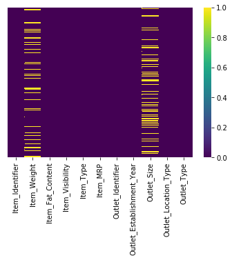

```python
# visualizing the data to detect missing values

sns.heatmap(testing_data.isnull(),yticklabels=False,cmap='viridis')
```

```python
testing_data.isnull().sum()
```

```
Item_Identifier                 0
Item_Weight                   976
Item_Fat_Content                0
Item_Visibility                 0
Item_Type                       0
Item_MRP                        0
Outlet_Identifier               0
Outlet_Establishment_Year       0
Outlet_Size                  1606
Outlet_Location_Type            0
Outlet_Type                     0
dtype: int64
```

```python
testing_data['Outlet_Size'].value_counts()
```

```
Medium    1862
Small     1592
High       621
Name: Outlet_Size, dtype: int64
```

```python
print(testing_data['Outlet_Size'].mode())
```

```
0    Medium
dtype: object
```

```python
# Impute the missing values in the Item_Weight size column.


testing_data.Outlet_Size = testing_data.Outlet_Size.fillna('Medium')
```

```python
print(testing_data['Item_Weight'].median())
```

```
12.5
```

```python
# Impute Missing values in the Item_Weight column by the mean value.


testing_data.Item_Weight = testing_data.Item_Weight.fillna(12.5)
```

```python
testing_data.isnull().sum()
```

```
Item_Identifier              0
Item_Weight                  0
Item_Fat_Content             0
Item_Visibility              0
Item_Type                    0
Item_MRP                     0
Outlet_Identifier            0
Outlet_Establishment_Year    0
Outlet_Size                  0
Outlet_Location_Type         0
Outlet_Type                  0
dtype: int64
```

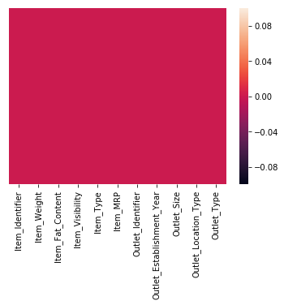

```python
# Visualizing the data to detect missing values after imputation

sns.heatmap(testing_data.isnull(),yticklabels=False)
```

```python
# Changing categorical data(Outlet_Location_Type) to numerical data.


testing_data["Outlet_Location_Type"] = pd.Categorical(testing_data["Outlet_Location_Type"])
Outlet_Location_Type_categories = testing_data.Outlet_Location_Type.cat.categories
testing_data["Outlet_Location_Type"] = testing_data.Outlet_Location_Type.cat.codes
```

```python
# Changing categorical data(Outlet_Size) to numerical data.


testing_data["Outlet_Size"] = pd.Categorical(testing_data["Outlet_Size"])
Outlet_Size_categories = testing_data.Outlet_Size.cat.categories
testing_data["Outlet_Size"] = testing_data.Outlet_Size.cat.codes
```

```python
# Changing categorical data(Item_Fat_Content) to numerical data.


testing_data["Item_Fat_Content"] = pd.Categorical(testing_data["Item_Fat_Content"])
Item_Fat_Content_categories = testing_data.Item_Fat_Content.cat.categories
testing_data["Item_Fat_Content"] = testing_data.Item_Fat_Content.cat.codes
```

```python
# Changing categorical data(Item_Type) to numerical data.


testing_data["Item_Type"] = pd.Categorical(testing_data["Item_Type"])
Item_Type_categories = testing_data.Item_Type.cat.categories
testing_data["Item_Type"] = testing_data.Item_Type.cat.codes
```

```python
# Changing categorical data(Outlet_Type) to numerical data.


testing_data["Outlet_Type"] = pd.Categorical(testing_data["Outlet_Type"])
Outlet_Type_categories = testing_data.Outlet_Type.cat.categories
testing_data["Outlet_Type"] = testing_data.Outlet_Type.cat.codes
```

```python
# Changing categorical data(Outlet_Identifier) to numerical data.


testing_data["Outlet_Identifier"] = pd.Categorical(testing_data["Outlet_Identifier"])
Outlet_Identifier_categories = testing_data.Outlet_Identifier.cat.categories
testing_data["Outlet_Identifier"] = testing_data.Outlet_Identifier.cat.codes
```

```python
# Changing categorical data(Outlet_Establishment_Year) to numerical data.


testing_data["Outlet_Establishment_Year"] = pd.Categorical(testing_data["Outlet_Establishment_Year"])
Outlet_Establishment_Year_categories = testing_data.Outlet_Establishment_Year.cat.categories
testing_data["Outlet_Establishment_Year"] = testing_data.Outlet_Establishment_Year.cat.codes
```

```python
# Testing data after categorical to numerical conversions.


testing_data.head(10)
```

|  | Item_Identifier | Item_Weight | Item_Fat_Content | Item_Visibility | Item_Type | Item_MRP | Outlet_Identifier | Outlet_Establishment_Year | Outlet_Size | Outlet_Location_Type | Outlet_Type |
| --- | --- | --- | --- | --- | --- | --- | --- | --- | --- | --- | --- |
| 0 | FDW58 | 20.750 | 1 | 0.007565 | 13 | 107.8622 | 9 | 4 | 1 | 0 | 1 |
| 1 | FDW14 | 8.300 | 4 | 0.038428 | 4 | 87.3198 | 2 | 7 | 1 | 1 | 1 |
| 2 | NCN55 | 14.600 | 1 | 0.099575 | 11 | 241.7538 | 0 | 3 | 1 | 2 | 0 |
| 3 | FDQ58 | 7.315 | 1 | 0.015388 | 13 | 155.0340 | 2 | 7 | 1 | 1 | 1 |
| 4 | FDY38 | 12.500 | 2 | 0.118599 | 4 | 234.2300 | 5 | 0 | 1 | 2 | 3 |
| 5 | FDH56 | 9.800 | 2 | 0.063817 | 6 | 117.1492 | 8 | 2 | 2 | 0 | 1 |
| 6 | FDL48 | 19.350 | 2 | 0.082602 | 0 | 50.1034 | 3 | 8 | 1 | 2 | 2 |
| 7 | FDC48 | 12.500 | 1 | 0.015782 | 0 | 81.0592 | 5 | 0 | 1 | 2 | 3 |
| 8 | FDN33 | 6.305 | 2 | 0.123365 | 13 | 95.7436 | 7 | 5 | 1 | 1 | 1 |
| 9 | FDA36 | 5.985 | 1 | 0.005698 | 0 | 186.8924 | 2 | 7 | 1 | 1 | 1 |

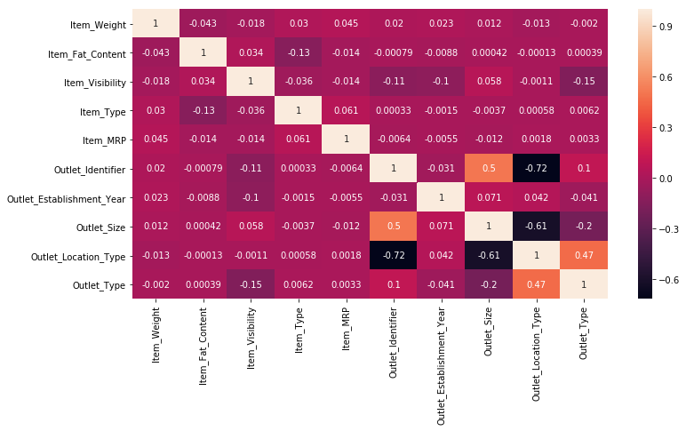

```python
# A correlation analysis will indicate additional relationships in the dataset

plt.figure(figsize=(12,6))
corr = testing_data.corr()
sns.heatmap(corr, annot=True)
```